# CITS4009 - Project 2

## Done By:

### Daniel Yi Wei Tan (22684196) and Abdul Momen Usmani (23685219)

### Part I: Scope and Introduction

The aim of this project is to build classification and clustering models based on the US Accident data set. This data set gives us information about 2000 observations/accidents that occurred over the years 2000-2015, including key variables like details of the accident, machinery used, experience of the individual and degree of the injury.

In the classification models, we use supervised learning models like Logistic regression and the Naive Bayes classifier on the training data to train our models, and then use the calibration and test sets to see how well our models perform. Our question in mind is to **predict whether an accident is serious** based on our other independent variables. We then do a comparison on which method produces more accurate results.

In unsupervised learning, clustering techniques like k-Means are used on numerical variables in the model to draw clusters, which groups similar observations with each other.

**Before starting, we import the relevant libraries:**

```r
library(dplyr)
library(cdlTools)
library(knitr)
library(ROCR)
library(ROCit)
library(ggplot2)
library(gridExtra)
library(caret)
library(pander)
library(fpc)
library(gridExtra)
library(ggpubr)
library(formattable)
```

**Importing the dataset and looking at the variables:**

```r
accident.raw = read.csv("us_data_2000.csv", header=T)
str(accident.raw)
```

```
'data.frame':   2000 obs. of  57 variables:
 $ MINE_ID            : int  100003 100003 100008 100011 100011 100011 100011 100011 100016 100021 ...
 $ CONTROLLER_ID      : chr  "41044" "41044" "M31753" "M11763" ...
 $ CONTROLLER_NAME    : chr  "Lhoist Group" "Lhoist Group" "Alan B  Cheney" "Imerys S A" ...
 $ OPERATOR_ID        : chr  "L13586" "L13586" "L31753" "L17074" ...
 $ OPERATOR_NAME      : chr  "Lhoist North America " "Lhoist North America " "Cheney Lime & Cement Company" "Imerys Pigments LLC" ...
 $ CONTRACTOR_ID      : chr  "" "" "" "" ...
 $ DOCUMENT_NO        : num  2.2e+11 2.2e+11 2.2e+11 2.2e+11 2.2e+11 ...
 $ SUBUNIT_CD         : int  3 30 30 30 30 30 30 30 3 3 ...
 $ SUBUNIT            : chr  "STRIP, QUARY, OPEN PIT" "MILL OPERATION/PREPARATION PLANT" "MILL OPERATION/PREPARATION PLANT" "MILL OPERATION/PREPARATION PLANT" ...
 $ ACCIDENT_DT        : chr  "14/03/2012" "8/01/2007" "4/07/2009" "26/05/2000" ...
 $ CAL_YR             : int  2012 2007 2009 2000 2005 2006 2008 2012 2000 2006 ...
 $ CAL_QTR            : int  1 1 3 2 1 1 4 2 3 1 ...
 $ FISCAL_YR          : int  2012 2007 2009 2000 2005 2006 2009 2012 2000 2006 ...
 $ FISCAL_QTR         : int  2 2 4 3 2 2 1 3 4 2 ...
```

[output cut: 43 more lines]

Upon observing a quick summary of the data, we can see that the data is fairly inconsistent in the sense that there are some variables that have a fair bit of missing data. Apart from that, we can also see that there are IDs tagged to certain cases, for example, accident types, injury sources and nature of injuries.

Additionally, there are some variables that may not be entirely relevant to our analysis as well, so we might as well remove those columns. We will do this in the next section.

### Part II: Data Cleaning and Outcome Selection

**Selecting our outcome variable** The question that our classification model aims to answer/predict is the seriousness of the injury, and the 2 columns that tell gives us the ground truth of our question are the variables “DEGREE_INJURY” and “DEGREE_INJURY_CD”, so we keep those variables in.

**Selecting the relevant variables using dplyr select:**

```r
accident = accident.raw %>% select(
  c("MINE_ID", "CONTROLLER_NAME", "OPERATOR_NAME", "SUBUNIT", "CAL_YR", "CAL_QTR", "ACCIDENT_TIME","DEGREE_INJURY", "DEGREE_INJURY_CD", "FIPS_STATE_CD", "MINING_EQUIP", "EQUIP_MFR_NAME", "SHIFT_BEGIN_TIME", "CLASSIFICATION", "ACCIDENT_TYPE", "TOT_EXPER", "MINE_EXPER", "JOB_EXPER", "OCCUPATION", "ACTIVITY", "INJURY_SOURCE", "NATURE_INJURY", "INJ_BODY_PART", "DAYS_LOST", "COAL_METAL_IND", "NO_INJURIES"))
remove(accident.raw)
```

The other variables look okay, but maybe we want to fix the state_id, just so we can see that variable easier and from which state it is from:

```r
accident$STATE_NAME = cdlTools::fips(accident$FIPS_STATE_CD, to ='Name')
accident = subset(accident, select = -FIPS_STATE_CD)
#str(accident)
```

**Classification Problem: We want to predict the seriousness of the accident, so let’s have a look at the variable:**

```r
table(accident$DEGREE_INJURY, accident$DEGREE_INJURY_CD)
```

```
                                   ?   0   1  10   2   3   4   5   6   7   8   9
  ACCIDENT ONLY                    0 219   0   0   0   0   0   0   0   0   0   0
  ALL OTHER CASES (INCL 1ST AID)   0   0   0  20   0   0   0   0   0   0   0   0
  DAYS AWAY FROM WORK ONLY         0   0   0   0   0 595   0   0   0   0   0   0
  DAYS RESTRICTED ACTIVITY ONLY    0   0   0   0   0   0   0 359   0   0   0   0
  DYS AWY FRM WRK & RESTRCTD ACT   0   0   0   0   0   0 145   0   0   0   0   0
  FATALITY                         0   0  11   0   0   0   0   0   0   0   0   0
  INJURIES DUE TO NATURAL CAUSES   0   0   0   0   0   0   0   0   0   0  10   0
  INJURIES INVOLVNG NONEMPLOYEES   0   0   0   0   0   0   0   0   0   0   0   3
  NO DYS AWY FRM WRK,NO RSTR ACT   0   0   0   0   0   0   0   0 552   0   0   0
  NO VALUE FOUND                  11   0   0   0   0   0   0   0   0   0   0   0
  OCCUPATNAL ILLNESS NOT DEG 1-6   0   0   0   0   0   0   0   0   0  57   0   0
  PERM TOT OR PERM PRTL DISABLTY   0   0   0   0  18   0   0   0   0   0   0   0
```

Given the table, we can see what level of the degree of injury is serious. A quick glance show that there is fatality, which is obviously serious, and a step down would be permanent and total disability. We also include higher levels of occupational illness, which could mean, according to some research, long term incurable illness caused by the accident.

**We remove observations with no value found first, as these do not contribute to the buliding of the model:**

```r
accident = accident[!accident$DEGREE_INJURY_CD == '?',]
```

We classify seriousness of the accident by: 1: Fatality (1), Permanent total/partial disability (2)/Occupational Illness (7) 0: All other degrees

**Mask, Create new variable for degree of accident and drop the other variables:**

```r
accident$DEG_ACCIDENT = (accident$DEGREE_INJURY_CD == 1 | accident$DEGREE_INJURY_CD == 2|accident$DEGREE_INJURY_CD == 7)
accident = subset(accident, select = -c(DEGREE_INJURY_CD, DEGREE_INJURY))
accident$DEG_ACCIDENT = ifelse(accident$DEG_ACCIDENT == T, 1, 0)
```

### The Null Model:

Before we start any single variable modelling, we check the null model first, which ignores all of the input features and only looks at the proportion of positive results.

```r
Npos = sum(accident[,"DEG_ACCIDENT"] == 1 )
pred.Null = Npos/nrow(accident)
cat("Proportion of outcome == 1 in full data:", pred.Null)
```

```
Proportion of outcome == 1 in full data: 0.04323781
```

**So, any of our other classifier models should perform better then the null model (0.04323781).**

### Splitting the data into training and test set.

In supervised learning, we need to separate our data into a training and test set. This is essential as we want to the observations in our training set solely for training our model, so in the test set, we can see how the model performs on data that is not used to train the model. This avoids over fitting the model as well.

```r
accident$DEG_ACCIDENT = factor(accident$DEG_ACCIDENT)
```

**We split the training and test set (90,10)**

```r
set.seed(4009)

vars = setdiff(colnames(accident), c('DEG_ACCIDENT', 'group'))

catVars = vars[sapply(accident[, vars], class) %in%
c('character','integer')]
numericVars = vars[sapply(accident[, vars], class) %in%
c('numeric')]

for (v in catVars) {
  if (class(accident[,v]) == "integer") {
    accident[,v] = as.character(accident[,v])
  }
}

accident$group = runif(dim(accident)[1])
trainingSet = subset(accident, group<= 0.9)
testSet = subset(accident, group>0.9)
```

Additionally, we want to further split our training data into a train set and a calibration set. The calibration set provides us with some measurement of uncertainty about our model.

**We split the training set into a train set and a calibration set (80,20)**

```r
calib.set = rbinom(dim(trainingSet)[1], size=1, prob=0.2)>0
accidentCal = subset(trainingSet, calib.set)
accidentTrain = subset(trainingSet, !calib.set)
```

### Part III: Single Variable Models

Single variable models gives us an insight into each of the variables that predicts our given outcome. The aim here is to look for the best, or rather the few best variables that explain the variation and gives us the best prediction on the outcome. We do this by using AUC curves and double density, which will be explained later on. Our final model, consisting of multiple variables, should perform better than the best single variable model, which we will observe later as well.

Before starting We observe one of the single variables.

```r
outcome = 'DEG_ACCIDENT'
pos = '1'

table.NI = table(trainingSet[,'NATURE_INJURY'], trainingSet[,outcome], useNA='ifany')
print(table.NI[,2]/(table.NI[,1]+table.NI[,2]))
```

```
AMPUTATION OR ENUCLEATION                ASBESTOSIS      BURN OR SCALD (HEAT)
               1.00000000                1.00000000                0.00000000
BURN,CHEMICL-FUME,COMPOUN CEREBRAL HEMORAGE-NT CCUS CONCUSSION-BRAIN,CEREBRAL
               0.00000000                0.00000000                0.00000000
CONTUSN,BRUISE,INTAC SKIN                  CRUSHING CUT,LACER,PUNCT-OPN WOUND
               0.00000000                0.09090909                0.00000000
DERMATITIS,RASH,SKIN INFL               DISLOCATION              DUST IN EYES
               1.00000000                0.00000000                0.00000000
ELECT SHOCK,ELECTROCUTION ELECT.ARC BURN-NOT CONTAC ELECTRIC BURN-CNTACT BURN
               0.00000000                0.00000000                0.00000000
            FRACTURE,CHIP HEARING LOSS OR IMPAIRMNT              HEART ATTACK
               0.00462963                1.00000000                0.00000000
HEATSTROK,SUNSTR,HT EXHAU            HERNIA;RUPTURE JOINT,TENDON,MUSCL INFLAM
               1.00000000                0.25000000                0.80645161
        MULTIPLE INJURIES            NO VALUE FOUND OCCUPATIONAL DISEASES,NEC
               0.10000000                0.00000000                1.00000000
 OTH RADIATION EFFECT,NEC          OTHER INJURY,NEC  OTHER PNEUMOCONIOSIS,NEC
               0.00000000                0.09090909                1.00000000
PNEUMOCONIOSIS,BLACK LUNG        POISONING,SYSTEMIC SCRATCH,ABRASION,SUPERFCL
               1.00000000                0.10000000                0.00000000
  SPRAIN,STRAIN RUPT DISC SUFFOC,SMOK INHILAT,DROWN UNCLASSIFIED,NOT DETERMED
               0.00000000                0.00000000                0.01694915
```

```r
remove(table.NI)
```

We see that in the NATURE_INJURY variable, AMPUTATION OR ENUCLEATION gives us a pure result, meaning that all outcomes with that type of injury always gives us a serious injury, likewise for hearing loss, heatstroke and asbestosis. However, something else that stands out might actually be the non-information of HEART ATTACK. In the natural sense, we would assume that heart attack is serious, but in this case did not result in a serious injury or accident. This could be an anomaly or just a singular occurance of a heart attack, which was not serious.

**Single Variable Models with Categorical Variables:**

Before we continue with our analysis, we first want to convert our categorical columns to a prediction columns with the proportion of observations that resulted in a serious injury. Due to the fact that some of the categorical columns have many levels/factors, this is an essential step to numericalize these variables so we can interpret them better, as also for our model to deal with numerical values than multilevel variables.

```r
mkPredC = function(outCol, varCol, appCol) {
  pPos <- sum(outCol == pos) / length(outCol)
  naTab <- table(as.factor(outCol[is.na(varCol)]))
  pPosWna <- (naTab/sum(naTab))[pos]
  vTab <- table(as.factor(outCol), varCol)
  pPosWv <- (vTab[pos, ] + 1.0e-3*pPos) / (colSums(vTab) + 1.0e-3)
  pred <- pPosWv[appCol]
  pred[is.na(appCol)] <- pPosWna
  pred[is.na(pred)] <- pPos
  pred
}

for(v in catVars) {
pi <- paste('pred', v, sep='')
accidentTrain[,pi] = mkPredC(accidentTrain[,outcome], accidentTrain[,v], accidentTrain[,v])
accidentCal[,pi] = mkPredC(accidentTrain[,outcome], accidentTrain[,v], accidentCal[,v])
testSet[,pi] = mkPredC(accidentTrain[,outcome], accidentTrain[,v], testSet[,v])
}
```

Checking some of the results:

```r
rows <- c(52, 47, 122, 109, 132, 23, 98, 154, 32)
accidentCal[rows, c("ACTIVITY", "predACTIVITY")]
```

|  | ACTIVITY | predACTIVITY |
| --- | --- | --- |
| 290 | OPERATE FRONT-END LOADER | 9.523560e-02 |
| 262 | HANDLING SUPPLIES/MATERIALS | 2.336458e-02 |
| 644 | NO VALUE FOUND | 2.510366e-07 |
| 558 | GET ON/OFF EQUIPMENT/MACHINES | 1.388929e-02 |
| 686 | HANDLING SUPPLIES/MATERIALS | 2.336458e-02 |
| 122 | WALKING/RUNNING | 4.208539e-07 |
| 494 | WALKING/RUNNING | 4.208539e-07 |
| 799 | NO VALUE FOUND | 2.510366e-07 |
| 158 | UNKNOWN | 6.749842e-01 |

**Single Variable Perfomances AUC and Deviance Reduction from the null model** To measure single variable model performance, we use AUC and deviance reduction, based on log likelihood to assess the quality of the classifier. A brief introduction and explaination of these 2 measures are given below:

**AUC** The AUC is built upon the receiver operating curve (ROC), that shows us the performance of a classification model at all classification thresholds, based on the two parameters: True Positive Rate (TPR) and False Positive Rate (FPR). (Google ML). AUC or Area Under the (ROC) Curve gives us an aggregate measure of performance across all possible classification thresholds. The bigger the AUC, the better the model is.

**Deviance Reduction** Deviance is defined by a difference in the log likelihoods, comparing the null model with the given model.

As we want to find the best single variable model based off the null model, we want to select the single variable model that gives us the largest deviance reduction to the null/saturated model.

**Helper Function for AUC**

```r
calcAUC <- function(predcol,outcol) {
perf <- performance(prediction(predcol,outcol==pos),'auc')
as.numeric(perf@y.values)
}
```

We then select the best categorical variables for further analysis, based on AUC. We can then apply a cutoff on the training AUC, and then look at the calibration AUC to assess the performance.

**AUC (Train and Calibration) Performance on Categorical Variables**

```r
bestCatVars = c()

for(v in catVars) {
pi = paste('pred', v, sep='')
aucTrain = calcAUC(accidentTrain[,pi], accidentTrain[,outcome])
if (aucTrain >= 0.9) {
aucCal = calcAUC(accidentCal[,pi], accidentCal[,outcome])
print(sprintf(
"%s: trainAUC: %4.3f; calibrationAUC: %4.3f",
pi, aucTrain, aucCal))
bestCatVars = c(bestCatVars, v)
}}
```

```
[1] "predMINE_ID: trainAUC: 0.989; calibrationAUC: 0.529"
[1] "predCONTROLLER_NAME: trainAUC: 0.957; calibrationAUC: 0.573"
[1] "predOPERATOR_NAME: trainAUC: 0.983; calibrationAUC: 0.564"
[1] "predACCIDENT_TIME: trainAUC: 0.926; calibrationAUC: 0.722"
[1] "predCLASSIFICATION: trainAUC: 0.926; calibrationAUC: 0.858"
[1] "predACTIVITY: trainAUC: 0.911; calibrationAUC: 0.765"
[1] "predINJURY_SOURCE: trainAUC: 0.943; calibrationAUC: 0.977"
[1] "predNATURE_INJURY: trainAUC: 0.995; calibrationAUC: 0.974"
[1] "predINJ_BODY_PART: trainAUC: 0.907; calibrationAUC: 0.921"
```

There are in total 9 variables that are of interest to us, or rather gives us a good accuracy of the outcome variable. In addition to this, to further cement our understanding and reduce our uncertainty of the measure, we perform 100 fold CV.

**100 Fold Cross-Validation**

```r
for (var in bestCatVars) {
  auc = rep(0, 100)
  for (j in 1:length(auc)) {
    useForCalRep = rbinom(n=nrow(trainingSet), size=1, prob=0.2) > 0
    predRep = mkPredC(trainingSet[!useForCalRep,outcome],
                      trainingSet[!useForCalRep,var],
                      trainingSet[useForCalRep,var])
    auc[j] = calcAUC(predRep, trainingSet[useForCalRep,outcome])
  }
print(sprintf("%s: mean: %4.3f; sd: %4.3f", var, mean(auc), sd(auc)))
}
```

```
[1] "MINE_ID: mean: 0.559; sd: 0.059"
[1] "CONTROLLER_NAME: mean: 0.636; sd: 0.069"
[1] "OPERATOR_NAME: mean: 0.632; sd: 0.068"
[1] "ACCIDENT_TIME: mean: 0.742; sd: 0.070"
[1] "CLASSIFICATION: mean: 0.901; sd: 0.055"
[1] "ACTIVITY: mean: 0.789; sd: 0.069"
[1] "INJURY_SOURCE: mean: 0.884; sd: 0.040"
[1] "NATURE_INJURY: mean: 0.981; sd: 0.015"
[1] "INJ_BODY_PART: mean: 0.863; sd: 0.039"
```

Given the 100 Fold CV, we can observe the following about the variables, based on the calibration AUC (1 Fold vs. 100 Fold) (Note: AUC might vary based on different runs, but should not deviate too far each other)

Most of the variables here do quite well, meaning that there is not a significant drop in the AUC between 1 fold and 100 fold, and some variables like OPERATOR_NAME even improved. We also look at the standard deviation of the CVs, which all are quite small. Hence, we can take for now that all these single variables contribute to the model. We shall put off plotting the AUC until we have all the variables that we know are significant to then compare with each other, including the numerical variables.

**The Double Density Plot** The double density plots gives us a visual understanding and representation of the predicted probabilities on the outcome variable.

**Helper Functions and Plotting the DD plots using ggplot**

```r
get_legend<-function(myggplot){
    tmp <- ggplot_gtable(ggplot_build(myggplot))
    leg <- which(sapply(tmp$grobs, function(x) x$name) == "guide-box")
    legend <- tmp$grobs[[leg]]
    return(legend)
    }

dd0 = ggplot(data=accidentCal) + geom_density(aes(x=predMINE_ID, color=factor(DEG_ACCIDENT)))
dd1= ggplot(data=accidentCal) + geom_density(aes(x=predMINE_ID, color=factor(DEG_ACCIDENT)))+  theme(legend.position = "none",axis.text.y = element_blank(),axis.title.y = element_blank())
dd2= ggplot(data=accidentCal) + geom_density(aes(x=predCONTROLLER_NAME, color=factor(DEG_ACCIDENT))) +  theme(legend.position = "none",axis.text.y = element_blank(),axis.title.y = element_blank())
dd3= ggplot(data=accidentCal) + geom_density(aes(x=predOPERATOR_NAME, color=factor(DEG_ACCIDENT))) +  theme(legend.position = "none",axis.text.y = element_blank(),axis.title.y = element_blank())
dd4= ggplot(data=accidentCal) + geom_density(aes(x=predACCIDENT_TIME, color=factor(DEG_ACCIDENT))) +  theme(legend.position = "none",axis.text.y = element_blank(),axis.title.y = element_blank())
dd5= ggplot(data=accidentCal) + geom_density(aes(x=predCLASSIFICATION, color=factor(DEG_ACCIDENT))) +  theme(legend.position = "none",axis.text.y = element_blank(),axis.title.y = element_blank())
dd6 = ggplot(data=accidentCal) + geom_density(aes(x=predINJURY_SOURCE, color=factor(DEG_ACCIDENT))) +  theme(legend.position = "none",axis.text.y = element_blank(),axis.title.y = element_blank())
dd7 = ggplot(data=accidentCal) + geom_density(aes(x=predNATURE_INJURY, color=factor(DEG_ACCIDENT))) +  theme(legend.position = "none",axis.text.y = element_blank(),axis.title.y = element_blank())
dd8 = ggplot(data=accidentCal) + geom_density(aes(x=predINJ_BODY_PART, color=factor(DEG_ACCIDENT))) +  theme(legend.position = "none",axis.text.y = element_blank(),axis.title.y = element_blank())
dd9= ggplot(data=accidentCal) + geom_density(aes(x=predACTIVITY, color=factor(DEG_ACCIDENT))) +  theme(legend.position = "none",axis.text.y = element_blank(),axis.title.y = element_blank())
legend  = get_legend(dd0)
```

**Observing the Double Density Plots**

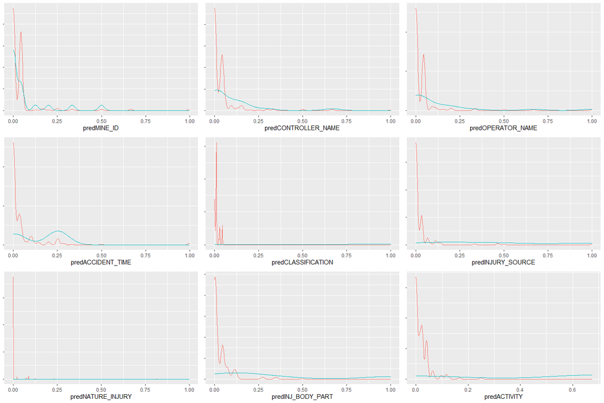

```r
grid.arrange(grobs = list(dd1,dd2,dd3,dd4,dd5,dd6,dd7,dd8,dd9), legend)
```

Based on the double density plots, we can obviously see that there are some variables that do better than others. Another observation is that the predicted densities for a serious injury (given by the blue line), is sometimes very flat to the point where it is hard to observe any patterns. This is because there are limited, or too few observations of the positive outcome in that variable. Normally, what we would like to observe is a discrepancy, or rather an observable difference between the blue (positive outcome) curve and the red (negative outcome) curve.

We see that some variables perform poorer than others, based on the explanation above, take for example MINE_ID, where there are a fair few observations that are positive, with predicted probabilities as 0. The optimal curve in this case, because of the few positive outcomes, is a flat line along density 0, with a kink towards the prediction 1. This is observed in the variables CLASSIFICATION, NATURE_INJURY and also ACTIVITY.

**Single Variable Models with Numerical Variables:** Here we are measuring the spread just like the way we do in boxplots and then converting the numerical variables to discretisized categorical levels

```r
numericVars
```

```
[1] "TOT_EXPER"  "MINE_EXPER" "JOB_EXPER"
```

```r
q01 <- quantile(trainingSet[,"TOT_EXPER"], probs=seq(0, 1, 0.1), na.rm=T) # remove NA
dis.VarTOT = cut(trainingSet[,"TOT_EXPER"], unique(q01))
q02 <- quantile(trainingSet[,"MINE_EXPER"], probs=seq(0, 1, 0.1), na.rm=T) # remove NA
dis.VarMINE = cut(trainingSet[,"MINE_EXPER"], unique(q02))
q03 <- quantile(trainingSet[,"JOB_EXPER"], probs=seq(0, 1, 0.1), na.rm=T) # remove NA
dis.VarJOB = cut(trainingSet[,"JOB_EXPER"], unique(q03))
```

**AUC (Train and Calibration) Performance on Numerical Variables**

```r
mkPredN = function(outCol, varCol, appCol) {
# compute the cuts
cuts <- unique(
quantile(varCol, probs=seq(0, 1, 0.1), na.rm=T)) # discretize the numerical columns
varC <- cut(varCol,cuts)
appC <- cut(appCol,cuts)
mkPredC(outCol,varC,appC)
}
```

```r
for(v in numericVars) {
pi <- paste('pred', v, sep='')
accidentTrain[,pi] <- mkPredN(accidentTrain[,outcome], accidentTrain[,v], accidentTrain[,v])
accidentCal[,pi] <- mkPredN(accidentTrain[,outcome], accidentTrain[,v], accidentCal[,v])
testSet[,pi] <- mkPredN(accidentTrain[,outcome], accidentTrain[,v], testSet[,v])
aucTrain <- calcAUC(accidentTrain[,pi], accidentTrain[,outcome])
if(aucTrain >= 0.55) {
aucCal <- calcAUC(accidentCal[,pi], accidentCal[,outcome])
print(sprintf(
"%s: trainAUC: %4.3f; calibrationAUC: %4.3f",
pi, aucTrain, aucCal))
}
}
```

```
[1] "predTOT_EXPER: trainAUC: 0.638; calibrationAUC: 0.622"
[1] "predMINE_EXPER: trainAUC: 0.651; calibrationAUC: 0.678"
[1] "predJOB_EXPER: trainAUC: 0.648; calibrationAUC: 0.643"
```

We can see that our AUC on the numerical variables, given training and calibration AUC are not far off from each other, which is a bit suspect, and might indicate that the numerical variables do not give good and accurate predictions of the positive outcome. Therefore, we then proceed to do 100 Fold CV to check this result

**100 Fold CV: to check the accuracy of the AUC for the given variables.**

```r
for (var in numericVars) {
  auc = rep(0, 100)
  for (j in 1:length(auc)) {
    useForCalRep = rbinom(n=nrow(trainingSet), size=1, prob=0.2) > 0
    predRep = mkPredC(trainingSet[!useForCalRep,outcome],
                      trainingSet[!useForCalRep,var],
                      trainingSet[useForCalRep,var])
    auc[j] = calcAUC(predRep, trainingSet[useForCalRep,outcome])
  }
print(sprintf("%s: mean: %4.3f; sd: %4.3f", var, mean(auc), sd(auc)))
}
```

```
[1] "TOT_EXPER: mean: 0.459; sd: 0.078"
[1] "MINE_EXPER: mean: 0.440; sd: 0.069"
[1] "JOB_EXPER: mean: 0.452; sd: 0.084"
```

**Double Density plots:**

```r
dd0 = ggplot(data=accidentCal) + geom_density(aes(x=predTOT_EXPER, color=factor(DEG_ACCIDENT)))
ddn1 = ggplot(data=accidentCal) + geom_density(aes(x=predTOT_EXPER, color=factor(DEG_ACCIDENT))) + theme(legend.position = "none",axis.text.y = element_blank(),axis.title.y = element_blank())
ddn2 = ggplot(data=accidentCal) + geom_density(aes(x=predMINE_EXPER, color=factor(DEG_ACCIDENT))) + theme(legend.position = "none",axis.text.y = element_blank(),axis.title.y = element_blank())
ddn3 = ggplot(data=accidentCal) + geom_density(aes(x=predJOB_EXPER, color=factor(DEG_ACCIDENT))) +theme(legend.position = "none",axis.text.y = element_blank(),axis.title.y = element_blank())
legendn = get_legend(dd0)
```

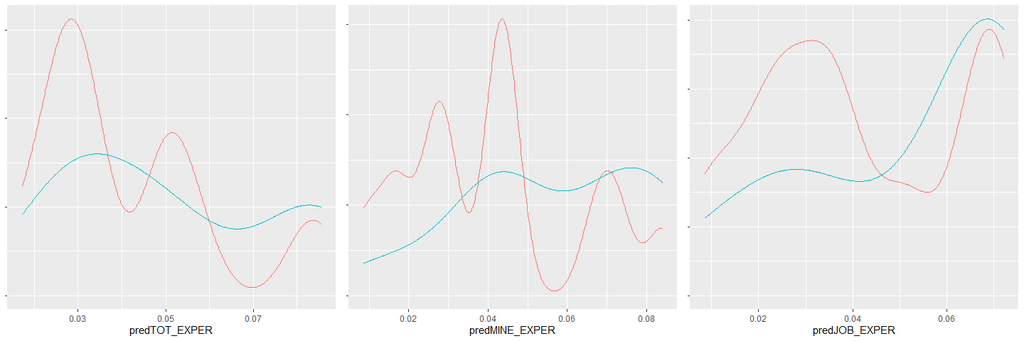

```r
grid.arrange(grobs = list(ddn1,ddn2,ddn3), legendn, ncol=3)
```

We can see here that the double density plots are quite erratic, and do not display any clear pattern or distinction between the positive and negative predicted probabilities.

**Feature Selection using log Likelihood:**

```r
logLikelihood <- function(ytrue, ypred, epsilon=1e-6, pos=1) {
  sum(ifelse(ytrue==pos, log(ypred+epsilon), log(1-ypred+epsilon)), na.rm=T)
}
```

Calculating the likelihood of the null model on the calibration set and then pick variables based on the reduction of deviance w.r.t to Null deviance

```r
outcome = 'DEG_ACCIDENT'

logNull = logLikelihood( accidentCal[,outcome],sum(accidentCal[,outcome]==pos)/nrow(accidentCal) )
logNull
```

```
[1] -77.85961
```

```r
selectCatVars = c()
minDrop = 5

for (v in catVars) {
  pi = paste('pred', v, sep='')
  devDrop = 2*(logLikelihood(accidentCal[,outcome], accidentCal[,pi])- logNull)
  if (devDrop >= minDrop) {
    print(sprintf("%s, deviance reduction: %g", pi, devDrop))
    selectCatVars = c(selectCatVars, pi)
  }
}
```

```
[1] "predCLASSIFICATION, deviance reduction: 59.8509"
[1] "predACCIDENT_TYPE, deviance reduction: 43.5716"
[1] "predINJURY_SOURCE, deviance reduction: 78.2993"
[1] "predNATURE_INJURY, deviance reduction: 94.1886"
[1] "predINJ_BODY_PART, deviance reduction: 65.9826"
```

Based on the result here we observe that the predictor NATURE_INJURY on the calibration set gives us the largest reduction to deviance. We compare this to the AUC calculated above, which confirms our understanding that the nature of injuries contributes largest to the degree of injury.

Likewise for the numerical variables, picking the variables based on their reduction with respect to the null deviance

```r
selectNumVars = c()
minDrop = 5

for (v in numericVars) {
  pi = paste('pred', v, sep='')
  devDrop = 2*(logLikelihood(accidentCal[,outcome], accidentCal[,pi])- logNull)
  if (devDrop >= minDrop) {
    print(sprintf("%s, deviance reduction: %g", pi, devDrop))
    selectNumVars = c(selectNumVars, pi)}
}
```

```
[1] "predMINE_EXPER, deviance reduction: 5.73873"
```

Looking at the numerical variables, we can see that the deviance reduction is positive only for the MINE_EXPER variable, so we pick that to be in our model building.

Therefore, we choose the 6 variables below to build our model:

```r
selectVars = c(selectCatVars, selectNumVars)
selectVars
```

```
[1] "predCLASSIFICATION" "predACCIDENT_TYPE"  "predINJURY_SOURCE"  "predNATURE_INJURY"
[5] "predINJ_BODY_PART"  "predMINE_EXPER"
```

Now that we have our 6 best variables, we plot our ROC curves to compare how well each does to each other, as well as w.r.t to the null model (the diagonal line)

**ROC Curves for selected categorical and numerical variables:**

```r
plot_roc <- function(predcol, outcol, colour_id=2, overlaid=F) {
ROCit_obj <- rocit(score=predcol, class=outcol==pos)
par(new=overlaid)
plot(ROCit_obj, col = c(colour_id, 1),
legend = FALSE, YIndex = FALSE, values = FALSE)
}
```

```r
plot_roc(accidentCal$predNATURE_INJURY, accidentCal[,"DEG_ACCIDENT"])
plot_roc(accidentCal$predCLASSIFICATION, accidentCal[,"DEG_ACCIDENT"], colour_id = 'purple', overlaid = T)
```

```r
plot_roc(accidentCal$predINJ_BODY_PART, accidentCal[,"DEG_ACCIDENT"], colour_id = 'yellow', overlaid = T)
plot_roc(accidentCal$predINJURY_SOURCE, accidentCal[,"DEG_ACCIDENT"], colour_id = 'blue', overlaid = T)
```

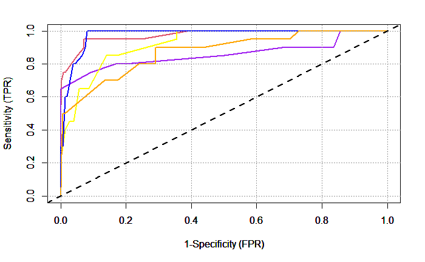

```r
plot_roc(accidentCal$predACCIDENT_TYPE, accidentCal[,"DEG_ACCIDENT"], colour_id = 'orange', overlaid = T)
plot_roc(accidentCal$predMINE_EXPER, accidentCal[,"DEG_ACCIDENT"], colour_id = 'green', overlaid = T)
```

### Part IV: Classification Models (Logistic Regression)

Logistic Regression Model: We use the reprocessed variables, which hides the categorical levels with numeric predictions. In this case for our dataset, this makes sense because the variables that we are using have a large amount of variables, and if we split the dataset into a training, calibration and test one, then we might run into the problem of the one or more of the variables not in either set, which will cause a problem in the model running.

**Using the Caret Library to build Logistic Regression Model** Logistic Regression Model on the 6 variables

```r
model.log = caret::train(x=accidentTrain[selectVars], y=accidentTrain[,'DEG_ACCIDENT'], method='glm', family=binomial(link='logit'), metric="Accuracy")
```

Looking at the summary of the Logistic Regression Model:

```r
model.log
```

```
Generalized Linear Model

1421 samples
   6 predictor
   2 classes: '0', '1'

No pre-processing
Resampling: Bootstrapped (25 reps)
Summary of sample sizes: 1421, 1421, 1421, 1421, 1421, 1421, ...
Resampling results:

  Accuracy   Kappa
  0.9925352  0.9012026
```

**ML Evaluation Metrics on Accuracy and Kappa:**

- The accuracy of the training set is 99.3%, which tells us the percentage of correctly classified instances out of all observations

Using the model on the calibration and test data:

**Calculating the AUC on the 3 sets, training, calibration and test set.**

```r
# Training Set
calcAUC(as.numeric(as.character(predict(model.log, newdata = accidentTrain))),accidentTrain[,outcome])
```

```
[1] 0.9418877
```

```r
# Calibration Set
calcAUC(as.numeric(as.character(predict(model.log, newdata = accidentCal))), accidentCal[,outcome])
```

```
[1] 0.8735755
```

```r
# Test Set
calcAUC(as.numeric(as.character(predict(model.log, newdata = testSet))),testSet[,outcome])
```

```
[1] 0.6973958
```

From here, we can see that our AUC for all 3 sets. We observe that the AUC for the calibration model does not perform as well as the best single variable model INJURY_SOURCE, at only 0.87 compared to the 0.97 that the SVM had. This could be a result of overfitting.

**Performance Measures: Accuracy, Precision, Recall and F1 Score** Performance Measures are used to assess the goodness of fit or accuracy of a model. We shall briefly discuss the different measures below:

Accuracy: Provides the percentage of correctly predicted values Precision: True Positives over all predicted positive results Recall: True Positive over all actual positive results F1: Harmonic mean of precision and recall.

The log likelihood function to calculate F1 score.

```r
logLikelihood2 <- function(ytrue, ypred, epsilon=1e-6, pos=1) {
  sum(ifelse(ytrue==pos, log(ypred+epsilon), log(1-ypred+epsilon)), na.rm=T)
}
```

Testing whether my function works

```r
ypred.calibration = as.numeric(as.character(predict(model.log, newdata = accidentCal)))
ytrue.calibration = accidentCal[,outcome]
```

Performance Measures Function:

```r
performanceMeasures = function(ytrue, ypred, model.name = "model", threshold = 0.5)  {
  # normalised deviance
  dev.norm = -2 * logLikelihood(ytrue, ypred)/length(ypred)
  #confusion matrix:
  confMat = table(ytrue, ypred >= threshold)
  accuracy = sum(diag(confMat)) / sum(confMat)
  precision = confMat[2, 2] / sum(confMat[, 2])
  recall = confMat[2, 2] / sum(confMat[2, ])
  f1 = 2 * precision * recall / (precision + recall)
  data.frame(model = model.name, accuracy = accuracy, precision = precision, recall = recall, f1 = f1, dev.norm = dev.norm)
}
```

Helper Functions for Pander Table:

```r
panderOpt = function(){
panderOptions("plain.ascii",TRUE)
panderOptions("keep.trailing.zeros",TRUE)
panderOptions("table.style","simple")
}

pp_table = function(model, xtrain, ytrain, xtest, ytest, xcal, ycal, threshold =0.5){
  panderOpt()
  perf_justify = 'lrrrrr'

  pred_train = as.numeric(as.character(predict(model.log, newdata = accidentTrain)))
  pred_test = as.numeric(as.character(predict(model.log, newdata = testSet)))
  pred_cal =  as.numeric(as.character(predict(model.log, newdata = accidentCal)))

  train_df = performanceMeasures(ytrain,pred_train, model.name = 'training')
  cal_df = performanceMeasures(ycal,pred_cal, model.name = 'calibration')
  test_df = performanceMeasures(ytest,pred_test, model.name = 'test')

  perftable <- rbind(train_df, cal_df, test_df)
  pandoc.table(perftable, justify = perf_justify)
}
```

**Putting the Measures into a table for all 3 sets**

```r
pp_table(model.log, accidentTrain[selectCatVars],accidentTrain[,outcome]==pos,
testSet[selectCatVars],testSet[,outcome]==pos,
accidentCal[selectCatVars],accidentCal[,outcome]==pos, )
```

```
model           accuracy   precision   recall       f1   dev.norm
------------- ---------- ----------- -------- -------- ----------
training          0.9937      0.9643   0.8852   0.9231     0.1750
calibration       0.9838      0.9375   0.7500   0.8333     0.4469
test              0.9797      0.6667   0.4000   0.5000     0.5610
```

Based on the results of the performance measures for the 3 sets, we can see that the accuracy levels are very high, meaning that there is a good proportion of correctly classified results. Obviously, the scores are lower for the test set, and this is quite significant in the case of precision, recall and f1 scores, because of the small proportion of positive outcomes which pales in comparison to the negative outcomes. Therefore, just one misclassified prediction can bring down the score by a lot.

Plotting the AUC:

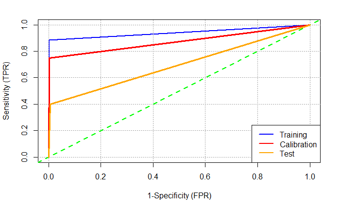

```r
plot_ROC = function(predcoltrain, outcoltrain, predcolcal, outcolcal, predcoltest, outcoltest) {
  roc_train = rocit(score=predcoltrain, class=outcoltrain==pos)
  roc_cal = rocit(score=predcolcal, class=outcolcal==pos)
  roc_test = rocit(score=predcoltest, class=outcoltest==pos)

  plot(roc_train, col=c('blue','green'), lwd=3,legend=FALSE,YIndex=FALSE,values=TRUE,asp=1)
  lines(roc_cal$TPR ~ roc_cal$FPR, lwd=3, col=c('red','green'), asp=1)
  lines(roc_test$TPR ~ roc_test$FPR, lwd=3, col=c('orange','green'), asp=1)
  legend("bottomright",col=c("blue",'red','orange'), c("Training","Calibration","Test"),lwd=2)
}

pred_train = as.numeric(as.character(predict(model.log, newdata = accidentTrain)))
pred_test = as.numeric(as.character(predict(model.log, newdata = testSet)))
pred_cal =  as.numeric(as.character(predict(model.log, newdata = accidentCal)))

plot_ROC(
  pred_train, accidentTrain[[outcome]], pred_cal, accidentCal[[outcome]], pred_test, testSet[[outcome]])
```

We can observe that the AUC for the training set and calibration scores are quite good, but there is a significant drop in the test set.

### Part V: Classification Models (Naive Bayes)

**Using the Caret Library to build NB Model**

```r
model.nb = caret::train(x=accidentTrain[selectCatVars], y=accidentTrain[,'DEG_ACCIDENT'], method='nb', metric="Accuracy");
model.nb
```

```
Naive Bayes

1421 samples
   5 predictor
   2 classes: '0', '1'

No pre-processing
Resampling: Bootstrapped (25 reps)
Summary of sample sizes: 1421, 1421, 1421, 1421, 1421, 1421, ...
Resampling results across tuning parameters:

  usekernel  Accuracy   Kappa
  FALSE      0.9736290  0.7429305
   TRUE      0.9594482  0.1721255

Tuning parameter 'fL' was held constant at a value of 0
Tuning parameter 'adjust' was
 held constant at a value of 1
Accuracy was used to select the optimal model using the largest value.
The final values used for the model were fL = 0, usekernel = FALSE and adjust = 1.
```

**Calculating the AUC scores for all sets.**

```r
# Training Set
calcAUC(as.numeric(as.character(predict(model.nb, newdata = accidentTrain))),accidentTrain[,outcome])
```

```
[1] 0.9312259
```

```r
# Calibration Set
calcAUC(as.numeric(as.character(predict(model.nb, newdata = accidentCal))), accidentCal[,outcome])
```

```
[1] 0.938604
```

```r
# Test Set
calcAUC(as.numeric(as.character(predict(model.nb, newdata = testSet))),testSet[,outcome])
```

```
[1] 0.6765625
```

The values of AUC on Training set and the Calibration set turns out to be good since they are quite high.

Performance Measures: Accuracy, Precision, Recall and F1 Score

The log likelihood function:

```r
logLikelihood2 <- function(ytrue, ypred, epsilon=1e-6, pos=1) {
  sum(ifelse(ytrue==pos, log(ypred+epsilon), log(1-ypred+epsilon)), na.rm=T)
}

ypred.calibration = as.numeric(as.character(predict(model.nb, newdata = accidentCal)))
ytrue.calibration = accidentCal[,outcome]
```

Performance Measures Function:

```r
performanceMeasures = function(ytrue, ypred, model.name = "model", threshold = 0.5)  {
  # normalised deviance
  dev.norm = -2 * logLikelihood(ytrue, ypred)/length(ypred)
  #confusion matrix:
  confMat = table(ytrue, ypred >= threshold)
  accuracy = sum(diag(confMat)) / sum(confMat)
  precision = confMat[2, 2] / sum(confMat[, 2])
  recall = confMat[2, 2] / sum(confMat[2, ])
  f1 = 2 * precision * recall / (precision + recall)
  data.frame(model = model.name, accuracy=accuracy, precision = precision, recall = recall, f1 = f1, dev.norm = dev.norm)
}
```

Helper Functions for Pander Table:

```r
panderOpt = function(){
panderOptions("plain.ascii",TRUE)
panderOptions("keep.trailing.zeros",TRUE)
panderOptions("table.style","simple")
}
```

A function to pretty print the performance table of a model on the training and test sets

```r
pp_table = function(model, xtrain, ytrain, xtest, ytest, xcal, ycal, mainLabel, threshold =0.5){
  panderOpt()
  perf_justify = 'lrrrrr'

  pred_train = as.numeric(as.character(predict(model, newdata = accidentTrain)))
  pred_test = as.numeric(as.character(predict(model, newdata = testSet)))
  pred_cal =  as.numeric(as.character(predict(model, newdata = accidentCal)))

  train_df = performanceMeasures(ytrain,pred_train, model.name = 'training')
  cal_df = performanceMeasures(ycal,pred_cal, model.name = 'calibration')
  test_df = performanceMeasures(ytest,pred_test, model.name = 'test')

  perftable <- rbind(train_df, cal_df, test_df)
  pandoc.table(perftable,caption = mainLabel, justify = perf_justify)
}
```

```r
pp_table(model.nb, accidentTrain[selectCatVars],accidentTrain[,outcome]==pos,
testSet[selectCatVars],testSet[,outcome]==pos,
accidentCal[selectCatVars],accidentCal[,outcome]==pos,"Naive Bayes", )
```

```
model           accuracy   precision   recall       f1   dev.norm
------------- ---------- ----------- -------- -------- ----------
training          0.9733      0.6353   0.8852   0.7397     0.7389
calibration       0.9730      0.6923   0.9000   0.7826     0.7448
test              0.9391      0.1818   0.4000   0.2500     1.6831

Table: Naive Bayes
```

```r
ypred.calibration = as.numeric(as.character(predict(model.nb, newdata = accidentCal)))
ytrue.calibration = accidentCal[,outcome]
```

**Plotting the AUC: NB**

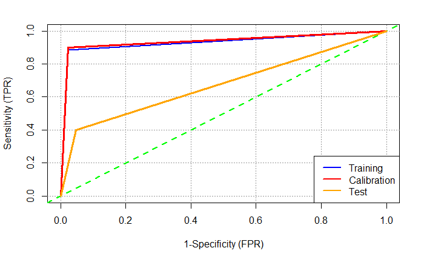

```r
plot_ROC = function(predcoltrain, outcoltrain, predcolcal, outcolcal, predcoltest, outcoltest) {
  roc_train = rocit(score=predcoltrain, class=outcoltrain==pos)
  roc_cal = rocit(score=predcolcal, class=ytrue.calibration==pos)
  roc_test = rocit(score=predcoltest, class=outcoltest==pos)

  plot(roc_train,col= c("blue","green"), lwd = 3,
       legend=FALSE,YIndex=FALSE,value=TRUE,asp=1)

  lines(roc_cal$TPR ~ roc_cal$FPR,lwd=3,col=c("red","green"), asp=1)
  lines(roc_test$TPR ~ roc_test$FPR,lwd=3,col=c("orange","green"), asp=1)
  legend("bottomright",col=c("blue","red","orange"), c("Training",
                                                      "Calibration",
                                                      "Test"), lwd=2)
}
pred_train = as.numeric(as.character(predict(model.nb, newdata = accidentTrain)))
pred_test = as.numeric(as.character(predict(model.nb, newdata = testSet)))
pred_cal = as.numeric(as.character(predict(model.nb, newdata = accidentCal)))

plot_ROC(pred_train, accidentTrain[[outcome]], pred_cal, accidentCal[[outcome]],
         pred_test, testSet[[outcome]])
```

### Part VI: Model Comparison

In this section, we want to compare which model provides us with the best accuracy, and we do this by looking at the model scores and AUC curves as shown below

```r
pp_table(model.log, accidentTrain[selectCatVars],accidentTrain[,outcome]==pos,
testSet[selectCatVars],testSet[,outcome]==pos,
accidentCal[selectCatVars],accidentCal[,outcome]==pos,"Logistic Regression" )
```

```
model           accuracy   precision   recall       f1   dev.norm
------------- ---------- ----------- -------- -------- ----------
training          0.9937      0.9643   0.8852   0.9231     0.1750
calibration       0.9838      0.9375   0.7500   0.8333     0.4469
test              0.9797      0.6667   0.4000   0.5000     0.5610

Table: Logistic Regression
```

```r
pp_table(model.nb, accidentTrain[selectCatVars],accidentTrain[,outcome]==pos,
testSet[selectCatVars],testSet[,outcome]==pos,
accidentCal[selectCatVars],accidentCal[,outcome]==pos,"Naive Bayes" )
```

```
model           accuracy   precision   recall       f1   dev.norm
------------- ---------- ----------- -------- -------- ----------
training          0.9733      0.6353   0.8852   0.7397     0.7389
calibration       0.9730      0.6923   0.9000   0.7826     0.7448
test              0.9391      0.1818   0.4000   0.2500     1.6831

Table: Naive Bayes
```

**Summary of AUC scores on both models:** Training - LR: 0.9418877, nb: 0.9312259 Calibration - LR: 0.8735755, nb: 0.938604 Test - LR: 0.697395, nb: 0.6765625

The performance table of the Logistic Regression Model turns out to be better than when we run the Naive-Bayes Model. The AUC of the Test Data for both the model shows that Logistic Regression has an upper hand of 0.70 whereas the AUC for the Test data of the Naive Bayes model turns out to be 0.67.

In the case of the normalized deviance of the Training sets of Logistic Regression is smaller than that of the Naive Bayes which tells us that Logistic Regression is better. Furthermore if we take a look at the normalized deviance of the Calibration sets we get to see that Logistic Regression performs better since the value is smaller. Thirdly the normalized deviance of the Test Set of Logistic Regression is smaller which tells us that Logistic Regression again performs better in this case.

On the other hand Precision of the Logistic Regression of the Training Set is more than Naive Bayes which indicates that Logistic Regression performs well. The Precision of the Test Set and the Calibration Set also performs better since these values are better than that of the Naive Bayes model.

Furthermore the Recall part of the Training set and the Test Set of the Logistic Regression and the Naive Bayes are the same, but differs in the Calibration Set where it tells us that Naive Bayes in this case performs better than that of the Logistic Regression since it values more than that of the Naive Bayes.

In case of the F1 Score the Training Set, the Calibration Set and the Test Set of both the Logistic Regression and the Naive Bayes it tells us that for all the three sets the value of the F1 score of the Logistic Regression is more than that of the Naive Bayes which tells us that Logistic Regression performs better than Naive Bayes

Overall the Performance measures shows that Logistic Regression performs slightly better.

**Side By Side AUC Curves**

```r
par(mfrow = c(1, 2))
plot_ROC(as.numeric(as.character(predict(model.log, newdata = accidentTrain))), accidentTrain[[outcome]], as.numeric(as.character(predict(model.log, newdata = accidentCal))), accidentCal[[outcome]], as.numeric(as.character(predict(model.log, newdata = testSet))), testSet[[outcome]])
title(main = "Logistic Regression")
```

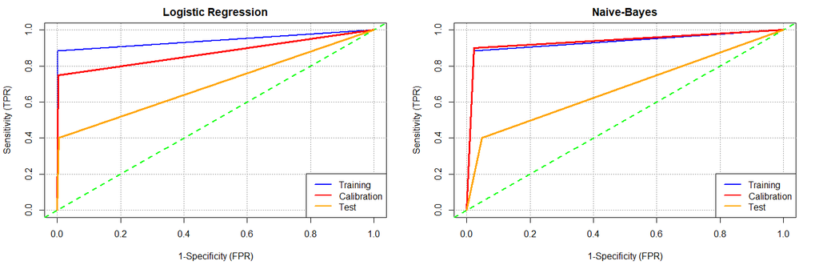

```r
plot_ROC(as.numeric(as.character(predict(model.nb, newdata = accidentTrain))), accidentTrain[[outcome]], as.numeric(as.character(predict(model.nb, newdata = accidentCal))), accidentCal[[outcome]],
as.numeric(as.character(predict(model.nb, newdata = testSet))), testSet[[outcome]])
title(main = "Naive-Bayes")
```

**LIME for the Logistic Regression Model:**

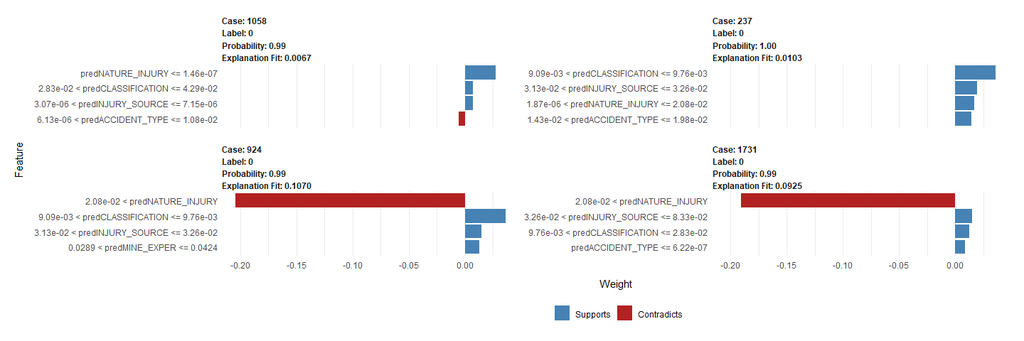

```r
###Logistic Regression
explainer <- lime(accidentTrain[selectVars], model = model.log,
                  bin_continuous = TRUE, n_bins = 10)

cases <- c(111,23,94,179)
example <- testSet[cases,selectVars]
explanation <- lime::explain(example, explainer, n_labels = 1, n_features = 4)
plot_features(explanation)
```

**LIME for the Naive Bayes Model:**

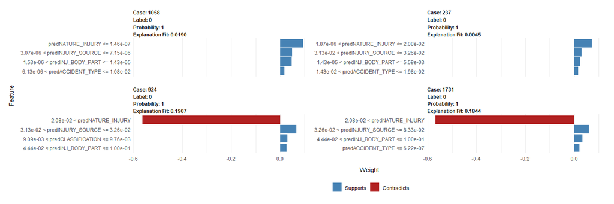

```r
###Naive Bayes
explainer2 <- lime(accidentTrain[selectVars], model = model.nb,
                  bin_continuous = TRUE, n_bins = 10)

cases2 <- c(111,23,94,179)
example2 <- testSet[cases2,selectVars]
explanation2 <- lime::explain(example2, explainer2, n_labels = 1, n_features = 4)
plot_features(explanation2)
```

While conducting LIME sanity checking on both the models we get to see that for the model formed by the Logistic Regression the Nature_Injury or the nature of injury plays a vital role in determining feature for the classification. Where the rest of the features are less significant. Whereas on the other model formed by the Naive Bayes model again the Nature_Injury feature plays an important role for the classification because it is significant, any feature other than that is insignificant.

## Part VI: Clustering

**Clustering Models:** In clustering, we use our numerical variables for unsupervised learning. Here, we focus on k-Means Clustering, which finds assigns each observation to each cluster center based on some distance parameter, in which we use the euclidean distance, which then repeats and reassigns the points until convergence, where all the points are assigned and stop moving.

Variable Selection and Scaling the data

```r
scale.accident = scale(accident)
```

Before we perform k-means, we require the data to be void of any NA variables, therefore, we use na.omit to clean the data. Disclaimer: When we remove the observations with NA, we are taking out almost half the data set. Here we might lose infomation, but having 1000 observations is still a good number to work with.

**K-Means Clustering** We start out by arbitrarily selecting a number which will define the number of clusters to test if kmeans will work on our dataset. However, we have to look for the optimal number of clusters given some of the heurisitcs which we will calculate and compare later.

```r
km1$cluster[1:20]
```

```
 [1] 1 1 1 1 1 1 5 3 5 5 3 1 3 2 1 1 1 1 3 1
```

Here we show the first 20 observations, and which cluster that they are assigned to out of the 5 clusters. And below, we show the cluster centers of each cluster on each given variable.

**Cluster Centers**

```r
km1$centers
```

```
   TOT_EXPER  MINE_EXPER   JOB_EXPER  DAYS_LOST DAYS_RESTRICT NO_INJURIES
1 -0.6374856 -0.49783080 -0.52936238 -0.2460952  -0.126610356   0.1642041
2  0.1010657 -0.03572046 -0.09691811  3.6914875  -0.249623540   0.2164407
3  0.8743446  0.18222646  0.67765209 -0.1960834  -0.172558028   0.1306300
4 -0.2120536 -0.02347758 -0.03567975 -0.2160042   4.958708851   0.1237334
5  1.7376673  2.32973977  1.63270019 -0.0254920  -0.006782489   0.1237334
```

**Simple Cluster Heuristics (Total SS, Within Cluster SS, Between Cluster SS)**

```r
km1$totss
```

```
[1] 5693.282
```

```r
km1$withinss
```

```
[1] 642.5772 264.7808 532.9561 240.0492 423.3331
```

```r
km1$betweenss
```

```
[1] 3589.586
```

**Finding the optimal number of clusters (kmeansruns)** To find the optimal number of clusters, we can use the library kmeansruns, which cross validates the kmeans criterion of either CH or ASW on each number of clusters, in this case we will limit from a minimum of 1 cluster to a maximum of 10 clusters.

The CH index is used as a measure of cluster goodness, where it is the ratio of the between cluster variance (B) and within cluster variance (W). Our aim is to maximise the the CH

The ASW or Average Silhouette Width is also used for assessment to find the optimal number of clusters, which we also want to maximise.

```r
k.ch = kmeansruns(scale.clean, krange=1:10, criterion='ch')
k.asw = kmeansruns(scale.clean, krange=1:10, criterion='asw')
```

**Looking for the Best k and Values for CH and ASW by number of clusters**

```r
k.ch$bestk
```

```
[1] 2
```

```r
k.asw$bestk
```

```
[1] 4
```

```r
k.ch$crit
```

```
 [1]   0.0000 530.7689 444.8918 473.5773 465.8262 439.1333 429.0308 416.6414 409.3806
[10] 406.0070
```

```r
k.asw$crit
```

```
 [1] 0.0000000 0.4761522 0.4968987 0.5164039 0.4303590 0.4370069 0.3940478 0.3958001
 [9] 0.4007384 0.4067259
```

**Plotting a Visual Line Plot for the Assessment of k**

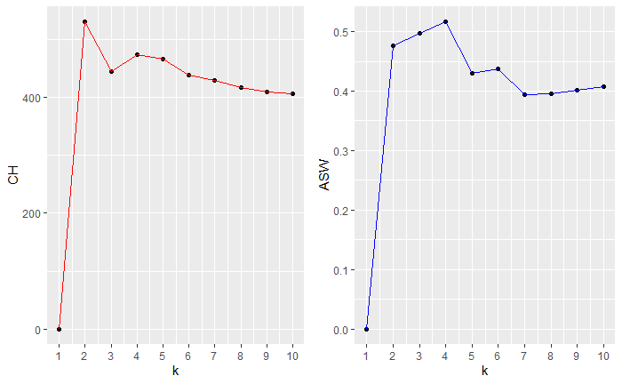

```r
kmcrit = data.frame(k=1:10, ch=k.ch$crit, asw=k.asw$crit)
ggkmeans1 = ggplot(kmcrit, aes(x=k, y=ch)) + geom_point() + geom_line(color='red') + labs(y='CH') + scale_x_continuous(breaks=1:10, labels=1:10)
ggkmeans2 = ggplot(kmcrit, aes(x=k, y=asw)) + geom_point() + geom_line(color='blue') + labs(y='ASW') + scale_x_continuous(breaks=1:10, labels=1:10)
grid.arrange(ggkmeans1,ggkmeans2,nrow=1)
```

We can see that using the 2 heuristic values, perhaps the better option is to choose 4 clusters. This is because the ASW is at its highest at 4 clusters. However, for CH the best choice is show to be 2, but there is also a second mode at 4, where after more than 4 clusters, the CH starts to drop off, so there is evidence that 4 clusters might be the optimal choice over 2.

**Running K-Means on 4 Optimal Clusters**

Now that we have concluded that the optimal number of clusters is 4, we can conduct k-means (k=4).

```r
km4 = kmeans(scale.clean, 4, iter.max = 100, nstart = 100)
km4$centers
```

```
   TOT_EXPER  MINE_EXPER   JOB_EXPER  DAYS_LOST DAYS_RESTRICT NO_INJURIES
1  1.4496832  1.21602497  1.33234402 -0.1397379    -0.1026244   0.1304569
2 -0.5007256 -0.42440930 -0.44058631 -0.2430018    -0.1346453   0.1590276
3 -0.1481136  0.06272864  0.03489644 -0.2147097     4.9126350   0.1237334
4  0.1665608 -0.06590331 -0.07546893  3.5537867    -0.2557230   0.2098187
```

```r
km4$size
```

```
[1] 239 774  28  56
```

We show the cluster centers again and this time see the number of observations that are being assigned to each cluster.

**Stability of Clusters** We use clusterboot. A bootstrap method to reduce the uncertainty of the stability of our clusters.

```r
1-cboot.kclust$bootbrd/1000
```

```
[1] 0.614 0.756 0.649 1.000
```

On 1000 clusterboot iterations, we can observe that our 2nd and last cluster are the most stable.

**Visualising the clusters in 2D, using best 2 principal components.**

```r
pca1 = prcomp(scale.clean)
ncomp = 2 # PC1 and PC2
project2D = as.data.frame(predict(pca1, newdata=scale.clean)[,1:ncomp])
kmeans2D = cbind(project2D, cluster=as.factor(km4$cluster))
```

**Convex Hull Function and plotting the clusters.**

[figure not shown]

```r
find_CHull = function(proj2Ddf,groups){
  do.call(rbind, lapply(unique(groups), FUN=function(c){
    f<-subset(proj2Ddf,cluster==c)
    f[chull(f),]
  }
  ))
}

k.meanshull = find_CHull(kmeans2D, km4$cluster)

ggplot(kmeans2D, aes(x=PC1, y=PC2)) + geom_point(aes(shape=cluster,color=cluster))+ geom_polygon(data=k.meanshull,aes(group=cluster,fill=as.factor(cluster)), alpha=0.4,linetype=0)+theme(text=element_text(size=10))
```

Finally, we plot our clusters on the PC1 and PC2 axes. We can see that the k-means clustering does a decent job at separating the clusters.

### Hierarchical Clustering:

**Using Cutree and Dendrogram Plot**

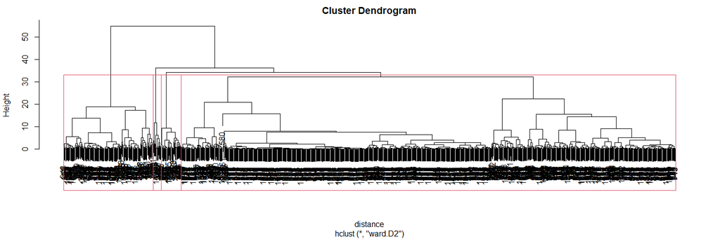

```r
distance = dist(scale.clean, method = 'euclidean')
pfit = hclust(distance, method = 'ward.D2')
plot(pfit)
rect.hclust(pfit, k=4)
```

We use the Euclidean distance to construct the dendrogram, and based on the 4 clusters that we have determined from the k-means algorithm, we can see how the dendrogram cuts the bottom up tree to the 4 clusters.

**Using the First 2 PCs to Visualise the Clustering (HC)**

```r
groups = cutree(pfit,k=4)
pca1 = prcomp(scale.clean)
ncomp = 2 # PC1 and PC2
project2D = as.data.frame(predict(pca1, newdata=scale.clean)[,1:ncomp])
hc2D = cbind(project2D, cluster=as.factor(groups))
hc2D
```

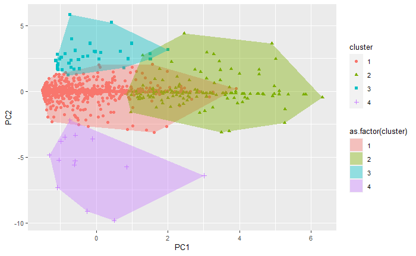

```r
find_CHull = function(proj2Ddf,groups){
  do.call(rbind, lapply(unique(groups), FUN=function(c){
    f<-subset(proj2Ddf,cluster==c)
    f[chull(f),]
  }
  ))
}

hc.hull = find_CHull(hc2D, groups)

ggplot(hc2D, aes(x=PC1, y=PC2)) + geom_point(aes(shape=cluster,color=cluster)) + geom_polygon(data=hc.hull,aes(group=cluster,fill=as.factor(cluster)), alpha=0.4,linetype=0)+theme(text=element_text(size=10))
```

Comparing the clusters in the above, we can see that the k-means does a better job of clustering, as there is minimal overlap of points in each cluster compared to the HC.

**Clusterboot on HC**

```r
1-cboot.hclust$bootbrd/1000
```

```
[1] 1.000 0.735 0.196 0.638
```